# Lab_4

Yehudis

3/12/2021

1. Consider the following example data for a between-subjects experiment with two groups, A and B:

```r
library(tibble)
example_data <- tibble(Group = rep(c("A","B"), each = 5),
                       DV = c(2,4,3,5,4,7,6,5,6,7))
```

Use R to conduct a t.test and ANOVA on this data. Then use R to prove that the results of both analyses are the same. For example, prove that the p-values are the same, and prove that the F-value and T-value are related. (3 points)

```r
#t-test
t_test <- t.test(DV~Group, var.equal=TRUE, data=example_data)

#anova
anova_test <- summary(aov(DV~Group, data=example_data))

#p value comparison
t_test$p.value
```

```
## [1] 0.003386143
```

```r
anova_test[[1]]$`Pr(>F)`[1]
```

```
## [1] 0.003386143
```

```r
t_test$p.value==anova_test[[1]]$`Pr(>F)`[1]
```

```
## [1] FALSE
```

```r
round(t_test$p.value, digits=5)==round(anova_test[[1]]$`Pr(>F)`[1], digits=5)
```

```
## [1] TRUE
```

```r
#=F + T relationship
t_test$statistic^2
```

```
##    t
## 16.9
```

```r
anova_test[[1]]$`F value`[1]
```

```
## [1] 16.9
```

```r
round(t_test$statistic^2, digits=1)==round(anova_test[[1]]$`F value`[1], digits=1)
```

```
##    t
## TRUE
```

2. Look at the lab on ANOVA that I wrote for our undergraduate statistics OER lab manual https://crumplab.github.io/statisticsLab/lab-8-one-way-anova.html. That lab shows an example of obtaining data from a published paper in psych science where a one-factor ANOVA was used as a part of the analysis. Load the data, conduct the ANOVA, report a ggplot of the means, and use papaja to help you write a short results section reporting the ANOVA result. (3 points).

```r
library(data.table)
#fread("https://raw.githubusercontent.com/CrumpLab/statisticsLab/master/data/Jamesetal2015Experiment2.csv")
all_data <- fread("Jamesetal2015Experiment2.csv")

view(all_data)

all_data$Condition <- as.factor(all_data$Condition)
levels(all_data$Condition) <- c("Control",
                                "Reactivation+Tetris",
                                "Tetris_only",
                                "Reactivation_only")

library(dplyr)
```

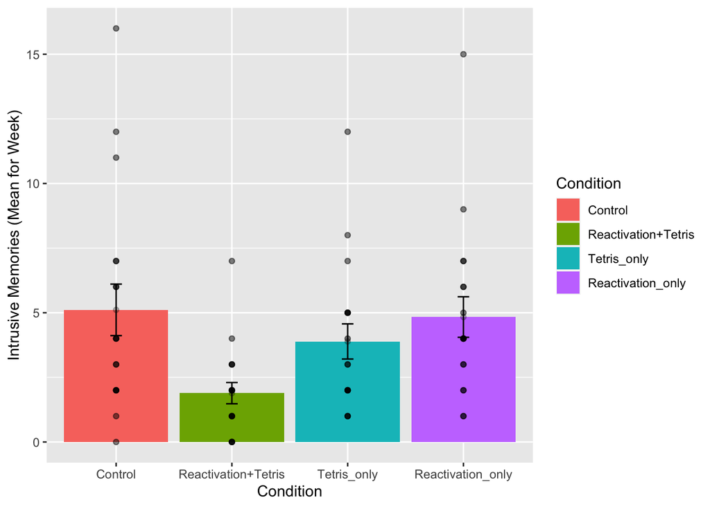

```r
library(ggplot2)

# get means and SEs
descriptive_df <- all_data %>%
                    group_by(Condition) %>%
                    summarise(means= mean(Days_One_to_Seven_Number_of_Intrusions),
                              SEs = sd(Days_One_to_Seven_Number_of_Intrusions)/sqrt(length(Days_One_to_Seven_Number_of_Intrusions)))
# Make the plot
ggplot(descriptive_df, aes(x=Condition, y=means))+
  geom_bar(stat="identity", aes(fill=Condition))+ # add means
  geom_errorbar(aes(ymin=means-SEs,               # add error bars
                    ymax=means+SEs), width=.1) +
  geom_point(data=all_data, aes(x=Condition, y=Days_One_to_Seven_Number_of_Intrusions), alpha=.5)+
  geom_point(alpha=.25)+
  ylab("Intrusive Memories (Mean for Week)")
```

```r
#ANOVA
aov(Days_One_to_Seven_Number_of_Intrusions ~ Condition, all_data)
```

```
## Call:
##    aov(formula = Days_One_to_Seven_Number_of_Intrusions ~ Condition,
##     data = all_data)
##
## Terms:
##                 Condition Residuals
## Sum of Squares   114.8194  685.8333
## Deg. of Freedom         3        68
##
## Residual standard error: 3.175812
## Estimated effects may be unbalanced
```

```r
summary(aov(Days_One_to_Seven_Number_of_Intrusions ~ Condition, all_data))
```

```
##             Df Sum Sq Mean Sq F value Pr(>F)
## Condition    3  114.8   38.27   3.795 0.0141 *
## Residuals   68  685.8   10.09
## ---
## Signif. codes:  0 '***' 0.001 '**' 0.01 '*' 0.05 '.' 0.1 ' ' 1
```

```r
anova_test2 <- summary(aov(Days_One_to_Seven_Number_of_Intrusions ~ Condition, all_data))
summary(anova_test2)
```

```
##      Length Class Mode
## [1,] 5      anova list
```

```r
#Report in APA style
library(papaja)
apa_print(anova_test2)$full_results$Condition
```

[output not shown]

Abdi, H., Edelman, B., Dowling, W. J., & Valentin, D. (2009). Experimental design and analysis for psychology. Oxford University Press. Crump, M. J. C., Navarro, D., & Suzuki, J. (2018). Answering questions with data: Introductory Statistics For Psychology Students. https://crumplab.github.io/statistics/